# Hair shedding joining and import

Harly Durbin

```r
source(here::here("source_functions/hair_ped.R"))
```

# Notes & questions

- Batch effects from non-integer data?
  - Could try building in an effect for study/source?
  - Or does contemporary group take care of that?
- How is foot score treated? Docility? As continuous?
- Changed `toxic_fescue` to `NO` for Texas scores
- Figure colors:
  - `#538797`: darker blue
  - `#C2D9CD`: lighter blue
  - `#FCAF1`: off-white
  - `#FF842A`: orange

- Age key based [here](http://www.angus.org/Nce/Documents/ByTheNumbers0108.pdf) and [BIF age of dam cutoffs](https://beefimprovement.org/wp-content/uploads/2013/07/BIFGuidelinesFinal_updated0916.pdf#23)

```r
# Had to do this programatically my brain was melting
age_key <-
  tibble(class = 1:25) %>%
  mutate(
    # The actual day you start being an age
    actual_start = class*365,
    # Mininum is higher for yearling
    min =
      case_when(
        class == 1 ~ 274,
        TRUE ~ actual_start - 90
      ),
    max = actual_start + 274,
    total_days = max - min
    ) %>%
  select(age_class = class, min, actual_start, max, total_days)
```

```
## mutate: new variable 'actual_start' with 25 unique values and 0% NA
```

```
##         new variable 'min' with 25 unique values and 0% NA
```

```
##         new variable 'max' with 25 unique values and 0% NA
```

```
##         new variable 'total_days' with 2 unique values and 0% NA
```

```
## select: dropped one variable (class)
```

```r
age_key
```

| age_class | min | actual_start | max | total_days |
| --- | --- | --- | --- | --- |
| 1 | 274 | 365 | 639 | 365 |
| 2 | 640 | 730 | 1004 | 364 |
| 3 | 1005 | 1095 | 1369 | 364 |
| 4 | 1370 | 1460 | 1734 | 364 |
| 5 | 1735 | 1825 | 2099 | 364 |
| 6 | 2100 | 2190 | 2464 | 364 |
| 7 | 2465 | 2555 | 2829 | 364 |
| 8 | 2830 | 2920 | 3194 | 364 |
| 9 | 3195 | 3285 | 3559 | 364 |
| 10 | 3560 | 3650 | 3924 | 364 |

[output cut: 15 more lines]

# Mizzou data

```r
animal_table <- read_rds(here::here("data/raw_data/animal_table.rds"))
```

- Pull records from Mizzou data where breed code is “AN” and/or listed breed association is “American Angus Association”
- Correct some registration numbers after searching in Pro Rodeo & find AAA registration for animals cross-registered in other breed associations
  - Drop hair scores from animals cancelled for parentage or not found

```r
mu_long <-
  # Mizzou hair shedding project cleaned data
  read_rds(here::here("data/raw_data/cleaned.rds")) %>%
    # janky registration corrections I did by searching Pro Rodeo
  left_join(animal_table %>%
              select(Lab_ID, Reg, breed_assoc, breed_assoc_reg)) %>%
  filter(breed_code == "AN" |
           breed_assoc == "American Angus Association") %>%
  filter(!farm_id %in% c("SAV", "BAT", "UMF")) %>%
  # janky registration corrections I did by searching Pro Rodeo
  left_join(
    read_excel(here::here("data/derived_data/reg_search.xlsx"), col_types = "text") %>%
      select(farm_id, animal_id, an_reg),
    by = c("farm_id", "animal_id"),
  ) %>%
  # Remove if cancelled for parentage or not found
  filter(an_reg != 0 | is.na(an_reg)) %>%
  mutate(
    # Pull from breed_assoc_reg (MU animal database)
    registration_number = case_when(
      # reg num found in Pro Rodeo
      # breed_assoc_reg from MU animal database
      # Diff breed reg, replace with Angus
      !is.na(an_reg) ~ an_reg,
      str_detect(breed_assoc_reg, "^1|^6") ~ breed_assoc_reg,
      # NA, replace with Angus
      is.na(registration_number) &
        str_detect(Reg, "^1|^6") ~ Reg,
      TRUE ~ registration_number
    ),
    # Fix toxic_fescue, calving season, date score recorded for some farms
    toxic_fescue =
      case_when(
        is.na(toxic_fescue) & farm_id %in% c("OHF", "GOF", "PVF") ~ "YES",
        is.na(toxic_fescue) & farm_id %in% c("LAF") ~ "NO",
        TRUE ~ toxic_fescue
      ),
    calving_season =
      case_when(
        farm_id %in% c("UMCT", "HAF", "GOF") ~ "SPRING",
        TRUE ~ calving_season
    ),
    date_score_recorded =
      case_when(
        is.na(date_score_recorded) & farm_id == "RCF" ~ ymd("2019-05-25"),
        TRUE ~ date_score_recorded
      ),
  ) %>%
  # Remove if still no registration number
  filter(!is.na(registration_number)) %>%
  # Remove if not an AAA or BIR reg
  filter(str_detect(registration_number, "^1|^6")) %>%
  select(animal_id,
         farm_id,
         breed_code,
         registration_number,
         barcode,
         sex,
         date_score_recorded,
         hair_score,
         age,
         calving_season,
         toxic_fescue,
         year,
         Lab_ID) %>%
  group_by(registration_number, date_score_recorded) %>%
  # Remove duplicates
  filter(n() == 1) %>%
  ungroup()
```

```
## select: dropped 34 variables (BC, NAAB, AIPL, Name, Sex, …)
```

```
## left_join: added 3 columns (Reg, breed_assoc, breed_assoc_reg)
```

```
##            > rows only in x     2,484
```

```
##            > rows only in y  (190,364)
```

```
##            > matched rows      32,443
```

```
##            >                 =========
```

```
##            > rows total        34,927
```

```
## filter: removed 22,034 rows (63%), 12,893 rows remaining
```

```
## filter: removed 4,046 rows (31%), 8,847 rows remaining
```

```
## select: dropped 4 variables (registration_number, barcode, Lab_ID, comment)
```

```
## left_join: added one column (an_reg)
```

```
##            > rows only in x   8,012
```

```
##            > rows only in y  (   22)
```

```
##            > matched rows       835
```

```
##            >                 =======
```

```
##            > rows total       8,847
```

```
## filter: removed 161 rows (2%), 8,686 rows remaining
```

```
## mutate: changed 148 values (2%) of 'registration_number' (0 new NA)
```

```
##         changed 636 values (7%) of 'calving_season' (634 fewer NA)
```

```
##         changed 2 values (<1%) of 'toxic_fescue' (2 fewer NA)
```

```
## filter: removed 24 rows (<1%), 8,662 rows remaining
```

```
## filter: removed 17 rows (<1%), 8,645 rows remaining
```

```
## select: dropped 9 variables (color, comment, temp_id, sold, dob, …)
```

```
## group_by: 2 grouping variables (registration_number, date_score_recorded)
```

```
## filter (grouped): removed 4 rows (<1%), 8,641 rows remaining
```

```
## ungroup: no grouping variables
```

# AGI Legacy data

```r
legacy_data <-
  # Raw Excel file provided by Mike MacNeil
  read_excel(here::here("data/raw_data/FinalFile(WW work)_MacNeil0619.xlsx"),
             na = "0") %>%
  janitor::clean_names() %>%
  # Remove empty rows and columns
  janitor::remove_empty(which = c("rows", "cols")) %>%
  select(
    farm_id = owner,
    location,
    registration_number = dam_reg,
    animal_id = cow_id,
    age = dam_bd,
    date_score_recorded = date,
    calf_dob = calf_bd,
    contains("hc"),
    region
  ) %>%
  # Convert from "wide" to "long" format:
  # One row per score-r per day
  reshape2::melt(
    id = c(
      "farm_id",
      "location",
      "registration_number",
      "animal_id",
      "age",
      "date_score_recorded",
      "calf_dob",
      "region"
    )
  ) %>%
  rename(scored_by = variable,
         hair_score = value) %>%
  mutate(
    scored_by = as.character(scored_by),
    registration_number = as.character(registration_number),
    scored_by = case_when(
      scored_by == "hcs" ~ "A",
      scored_by == "hc_sa" ~ "B",
      scored_by == "hc_sb" ~ "C"
    )
  ) %>%
  # Remove empty rows
  filter(!is.na(hair_score)) %>%
  # Impute toxic_fescue
  mutate(
    year = lubridate::year(date_score_recorded),
    date_score_recorded = ymd(date_score_recorded),
    toxic_fescue =
      case_when(
        # Presumably no hot fescue in TX
        region == "TX" ~ "NO",
        # In previous hair shedding paper, authors indicated that the entire NCSU Upper Piedmont research station herd grazes hot fescue
        farm_id %in% c("UPRS") ~ "YES",
        TRUE ~ NA_character_
      ),
    # Only cows scored in AGI data
    sex = "F",
    # Infer age from birth date and date scored
    age = as.integer(lubridate::time_length(
      ymd(date_score_recorded) - ymd(age), unit = "years"
    )),
    # Infer calving season from calf dob
    calving_season =
      case_when(
        between(
          lubridate::month(calf_dob),
          left = 1,
          right = 6
        ) ~ "SPRING",
        between(
          lubridate::month(calf_dob),
          left = 7,
          right = 12
        ) ~ "FALL"
      ),
    # collapse/rename some farm ids
    farm_id =
      case_when(
        farm_id %in% c("QH") ~ "QuakerHill",
        farm_id %in% c("4") ~ "Creswell",
        farm_id %in% c("A") ~ "bradley3",
        farm_id %in% c("B") ~ "RobertElliott",
        farm_id %in% c("I") ~ "Woodall",
        farm_id %in% c("F") ~ "Fleming",
        TRUE ~ farm_id
      )
  ) %>%
  group_by(registration_number, date_score_recorded) %>%
  # Take the mean of all scores for that day
  mutate(hair_score = mean(hair_score)) %>%
  ungroup() %>%
  select(-scored_by) %>%
  distinct()
```

```
## * `` -> ...28
## * `` -> ...34
## * `` -> ...35
```

```
## select: dropped 27 variables (dam_reg, date, owner, cow_id, bcs, …)
```

```
## rename: renamed 2 variables (scored_by, hair_score)
```

```
## mutate: converted 'registration_number' from double to character (0 new NA)
```

```
##         converted 'scored_by' from factor to character (0 new NA)
```

```
## filter: removed 5,809 rows (34%), 11,330 rows remaining
```

```
## mutate: changed 2,032 values (18%) of 'farm_id' (0 new NA)
```

```
##         converted 'age' from double to integer (0 new NA)
```

```
##         changed 0 values (0%) of 'date_score_recorded' (0 new NA)
```

```
##         new variable 'year' with 2 unique values and 0% NA
```

```
##         new variable 'toxic_fescue' with 3 unique values and 76% NA
```

```
##         new variable 'sex' with one unique value and 0% NA
```

```
##         new variable 'calving_season' with 2 unique values and 0% NA
```

```
## group_by: 2 grouping variables (registration_number, date_score_recorded)
```

```
## mutate (grouped): changed 3,944 values (35%) of 'hair_score' (0 new NA)
```

```
## ungroup: no grouping variables
```

```
## select: dropped one variable (scored_by)
```

```
## distinct: removed 5,618 rows (50%), 5,712 rows remaining
```

# Bradley 3 data

```r
# Tidy Bradley 3 hair shedding data provided by James Henderson
bradley3_data <-
  readxl::read_excel(here::here("data/raw_data/henderson_hair_shed.xlsx"),
           skip = 1) %>%
  # Select all columns but name
  dplyr::select(
    animal_id = 1,
    registration_number = 3,
    age = 4,
    hs19 = 5,
    hs18 = 6
    ) %>%
  # Change from column for each year to row for each observation
  reshape2::melt(id = c("animal_id", "registration_number", "age")) %>%
  dplyr::mutate(
    variable = case_when(
      variable == "hs19" ~ ymd("2019-05-01"),
      variable == "hs18" ~ ymd("2018-05-08")
      ),
    registration_number = as.character(registration_number)) %>%
  dplyr::rename(
    hair_score = value,
    date_score_recorded = variable
    ) %>%
  dplyr::mutate(
    farm_id = "bradley3",
    date_score_recorded = lubridate::ymd(date_score_recorded),
    year = lubridate::year(date_score_recorded),
    # Infer age from birth date and date scored
    age = as.integer(lubridate::time_length(
      date_score_recorded - lubridate::ymd(age), unit = "years"
      )),
    toxic_fescue = "NO",
    calving_season = "FALL"
    ) %>%
  # Remove empty rows
  dplyr::filter(!is.na(hair_score))
```

```
## * HS -> HS...5
## * HS -> HS...6
```

# Join & tidy

- Remove animals where sex on file does not match sex in pedigree
- Remove scores from animals where age on file > 2 year different from age based on DOB in pedigree

```r
angus_join <-
bind_rows(
  mu_long %>%
    mutate(source = "mizzou"),
  legacy_data %>%
    mutate(source = "legacy"),
  bradley3_data %>%
    mutate(source = "bradley3")
) %>%
  # full_reg with BIR or AAA pre-pended
  mutate(full_reg =
           case_when(
             str_detect(registration_number, "^6") ~ as.character(glue("BIR{registration_number}")),
             str_detect(registration_number, "^1") ~ as.character(glue("AAA{registration_number}"))
           )) %>%
  # Use for finding likely errors
  left_join(hair_ped %>%
              rename(sex_ped = sex,
                     dob_ped = dob),
            by = c("full_reg")) %>%
  # Pull in missing calving seasons from by-hand ProRodeo searching
  left_join(read_excel(
    here::here("data/derived_data/season_search.xlsx"),
    trim_ws = TRUE,
    skip = 1,
    col_names = c("farm_id", "registration_number", "year", "cs2")
  )) %>%
  # Fix incorrect calving seasons
  # For missing calving season, impute using dob
  mutate(
    calving_season =
      case_when(
        !is.na(cs2) ~ cs2,
        sex == "F" &
          is.na(calving_season) &
          between(lubridate::month(dob_ped), left = 1, right = 6) ~ "SPRING",
        sex == "F" &
          is.na(calving_season) &
          between(lubridate::month(dob_ped), left = 7, right = 12) ~ "FALL",
        TRUE ~ calving_season
      ),
    # Remove spaces from farm ID
    farm_id = str_remove(farm_id, " "),
    # Infer age in days using date score recorded
    age_ped =
      case_when(
        !is.na(date_score_recorded) ~ as.integer(date_score_recorded - dob_ped),
        # If no date scored provided, use May 1 of that year
        is.na(date_score_recorded) ~ as.integer(ymd(glue::glue("{year}-05-01")) - dob_ped)
      )
  ) %>%
  filter(age_ped >= 274) %>%
  # Age classes based on BIF age of dam
  mutate(
    age_class =
      case_when(
        between(age_ped, 274, 639) ~ 1,
        between(age_ped, 640, 1004) ~ 2,
        between(age_ped, 1005, 1369) ~ 3,
        between(age_ped, 1370, 1734) ~ 4,
        between(age_ped, 1735, 2099) ~ 5,
        between(age_ped, 2100, 2464) ~ 6,
        between(age_ped, 2465, 2829) ~ 7,
        between(age_ped, 2830, 3194) ~ 8,
        between(age_ped, 3195, 3559) ~ 9,
        between(age_ped, 3560, 3924) ~ 10,
        between(age_ped, 3925, 4289) ~ 11,
        between(age_ped, 4290, 4654) ~ 12,
        between(age_ped, 4655, 5019) ~ 13,
        between(age_ped, 5020, 5384) ~ 14,
        between(age_ped, 5385, 5749) ~ 15,
        between(age_ped, 5750, 6114) ~ 16,
        between(age_ped, 6115, 6479) ~ 17,
        between(age_ped, 6480, 6844) ~ 18,
        between(age_ped, 6845, 7209) ~ 19,
        between(age_ped, 7210, 7574) ~ 20,
        between(age_ped, 7575, 7939) ~ 21
      ),
    keep =
      case_when(
        # Remove if sex on file differs from sex in pedigree
        sex != sex_ped ~ "drop sex",
        # Remove if age on file greater than 2 years different than age in pedigree
        abs(age - age_class) > 2 ~ "drop age",
        TRUE ~ "keep"
        ),
    age =
      case_when(
        is.na(age_class) ~ as.integer(age),
        TRUE ~ as.integer(age_class)
      ),
    sex =
      case_when(
        is.na(sex_ped) ~ sex,
        TRUE ~ sex_ped
      ),
  ) %>%
  filter(!str_detect(keep, "drop")) %>%
  select(
    farm_id,
    location,
    animal_id,
    full_reg,
    registration_number,
    sex,
    date_score_recorded,
    year,
    hair_score,
    dob = dob_ped,
    age,
    calving_season,
    toxic_fescue,
    source,
    Lab_ID,
    barcode
  ) %>%
  # Add coordinates
  left_join(
    read_csv(here::here("data/raw_data/an_loc_key.csv"))
  ) %>%
  distinct()
```

```
## mutate: new variable 'source' with one unique value and 0% NA
## mutate: new variable 'source' with one unique value and 0% NA
## mutate: new variable 'source' with one unique value and 0% NA
```

```
## mutate: new variable 'full_reg' with 8,795 unique values and 0% NA
```

```
## rename: renamed 2 variables (sex_ped, dob_ped)
```

```
## left_join: added 5 columns (sex_ped, dob_ped, sire_reg, dam_reg, et_dam_reg)
```

```
##            > rows only in x       171
```

```
##            > rows only in y  (596,324)
```

```
##            > matched rows      14,844
```

```
##            >                 =========
```

```
##            > rows total        15,015
```

```
## left_join: added one column (cs2)
```

```
##            > rows only in x   14,831
```

```
##            > rows only in y  (     0)
```

```
##            > matched rows        184
```

```
##            >                 ========
```

```
##            > rows total       15,015
```

```
## mutate: changed 834 values (6%) of 'farm_id' (0 new NA)
```

```
##         changed 184 values (1%) of 'calving_season' (142 fewer NA)
```

```
##         new variable 'age_ped' with 2,996 unique values and 1% NA
```

```
## filter: removed 174 rows (1%), 14,841 rows remaining
```

```
## mutate: changed 664 values (4%) of 'sex' (662 fewer NA)
```

```
##         changed 684 values (5%) of 'age' (19 fewer NA)
```

```
##         new variable 'age_class' with 20 unique values and 0% NA
```

```
##         new variable 'keep' with 3 unique values and 0% NA
```

```
## filter: removed 6 rows (<1%), 14,835 rows remaining
```

```
## select: dropped 12 variables (breed_code, calf_dob, region, sex_ped, dob_ped, …)
```

```
## left_join: added 5 columns (zip, city, state, lat, lng)
```

```
##            > rows only in x        3
```

```
##            > rows only in y  (     0)
```

```
##            > matched rows     14,832
```

```
##            >                 ========
```

```
##            > rows total       14,835
```

```
## distinct: no rows removed
```

# Summary

- **Result:** 14835 scores from 8619 animals

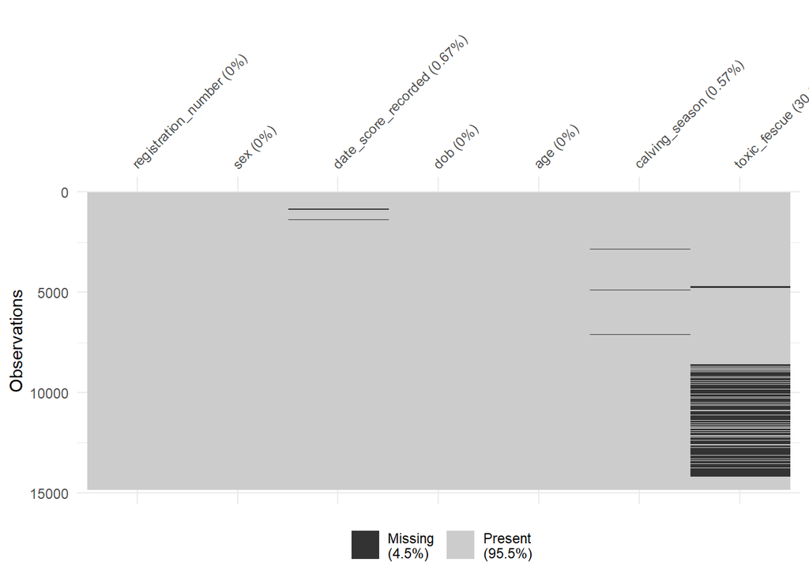

```r
angus_join %>%
    select(
    registration_number,
    sex,
    date_score_recorded,
    dob,
    age,
    calving_season,
    toxic_fescue
  ) %>%
  visdat::vis_miss()
```

- Number of scores per farm

```r
angus_join %>%
  group_by(farm_id) %>%
  tally(sort = TRUE)
```

| farm_id | n |
| --- | --- |
| UMCT | 1286 |
| OHF | 1195 |
| bradley3 | 1108 |
| FHC | 993 |
| Mead | 921 |
| Sydenstricker | 841 |
| CKC | 796 |
| RAAF | 705 |
| HAF | 662 |
| Yon | 564 |

[output cut: 40 more lines]

- Summary by source

```r
angus_join %>%
  mutate(source = if_else(source == "bradley3", "legacy", source)) %>%
  group_by(source) %>%
  summarise(n = n(),
            Mean = mean(hair_score),
            SD = sd(hair_score)) %>%
  bind_rows(
    angus_join %>%
      mutate(source = "All") %>%
      group_by(source) %>%
      summarise(
        n = n(),
        Mean = mean(hair_score),
        SD = sd(hair_score)
      )
  )
```

| source | n | Mean | SD |
| --- | --- | --- | --- |
| legacy | 6374 | 3.101323 | 1.145017 |
| mizzou | 8461 | 2.653469 | 1.145965 |
| All | 14835 | 2.845894 | 1.166777 |

## Score distribution

- Distribution of scores (rounded to nearest whole number) in legacy & Bradley3 data

```r
angus_join %>%
  mutate(source = if_else(source == "bradley3", "legacy", source),
         hair_score2 = round(hair_score, 0)) %>%
  filter(source == "legacy") %>%
  janitor::tabyl(hair_score2)
```

| hair_score2 | n | percent |
| --- | --- | --- |
| 1 | 364 | 0.05710700 |
| 2 | 2115 | 0.33181676 |
| 3 | 880 | 0.13806087 |
| 4 | 2487 | 0.39017885 |
| 5 | 528 | 0.08283652 |

- Distribution of scores in Mizzou data

```r
angus_join %>%
  mutate(hair_score2 = round(hair_score, 0)) %>%
  filter(source == "mizzou") %>%
  janitor::tabyl(hair_score2)
```

| hair_score2 | n | percent |
| --- | --- | --- |
| 1 | 1509 | 0.17834771 |
| 2 | 2489 | 0.29417327 |
| 3 | 2401 | 0.28377260 |
| 4 | 1549 | 0.18307529 |
| 5 | 513 | 0.06063113 |

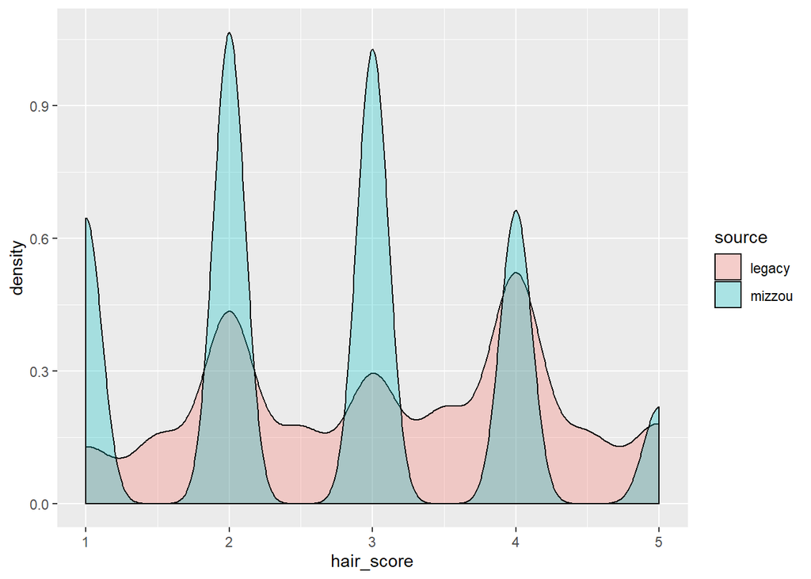

```r
angus_join %>%
  mutate(source = if_else(source == "bradley3", "legacy", source)) %>%
  ggplot(aes(x = hair_score, fill = source)) +
  geom_density(alpha = 0.3)
```

## Distribution of scoring timing across all years

```r
angus_join %>%
  mutate(date = ymd(format(angus_join$date_score_recorded, "2000-%m-%d"))) %>%
  summarise(min(date, na.rm = TRUE),
            max(date, na.rm = TRUE))
```

| min(date, na.rm = TRUE) | max(date, na.rm = TRUE) |
| --- | --- |
| 2000-04-17 | 2000-06-30 |

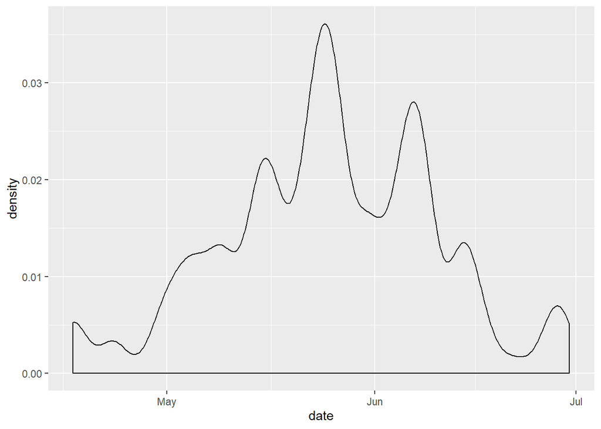

```r
angus_join %>%
  mutate(date = ymd(format(angus_join$date_score_recorded, "2000-%m-%d"))) %>%
  ggplot(aes(x = date)) +
  geom_density()
```

## Sex ratio

```r
angus_join %>%
  group_by(sex) %>%
  tally()
```

| sex | n |
| --- | --- |
| F | 14741 |
| M | 94 |

## Location of scores

```r
source(here::here("source_functions/hair_map.R"))
```

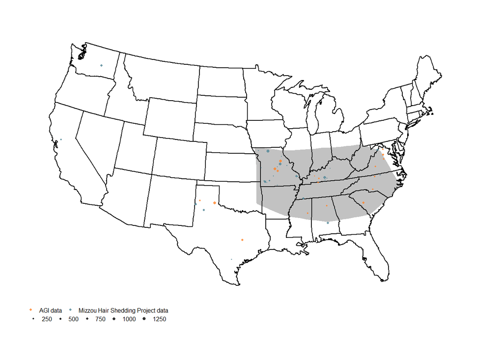

```r
#cowplot::ggsave2(filename = here::here("figures/figure2.hair_map.pdf"), width = 85, height = 52.4, units = "mm", dpi = 300)
```

## Number of records per animal

```r
angus_join %>%
  group_by(full_reg) %>%
  tally(sort = TRUE) %>%
  ungroup() %>%
  group_by(n) %>%
  summarise(n_animals = n()) %>%
  ungroup() %>%
  mutate(percent = scales::percent(n_animals/sum(n_animals)),
         n_animals = scales::comma(n_animals)) %>%
  rename(n_records = n)
```

| n_records | n_animals | percent |
| --- | --- | --- |
| 1 | 4,428 | 51.37% |
| 2 | 2,778 | 32.23% |
| 3 | 832 | 9.65% |
| 4 | 551 | 6.39% |
| 5 | 29 | 0.34% |
| 6 | 1 | 0.01% |

# Export

```r
angus_join %>%
  write_rds(here::here("data/derived_data/angus_join.rds"))
```

# Notes and commentary

Scores recorded on registered & BIR Angus cattle between 2016 and 2019 were extracted from the Mizzou Hair Shedding Project dataset. Records were dropped when the reported sex of an animal did not match the sex recorded in the AAA pedigree or and when the reported age differed from the age calculated using birth date recorded in the AAA pedigree for that registration by more than two years.  
When no calving season was reported, it was imputed using the most recent natural birth calving date prior to the recorded score. When no natural birth calving dates were available, calving season was imputed using birth date.  
In the AGI legacy project data, some animals were recorded by multiple scoring technicians on the same day. Where relevant, phenotypes recorded on the same animal on the same day were averaged. Fescue grazing status was not recorded in this data, but animals scored in Texas were assumed to not have grazed endophyte-infected fescue in spring of the scoring year.  
This resulted in 8,461 scores recorded on 3,840 animals in the Mizzou Hair Shedding Project and 6,374 scores recorded on 4,781 in the AGI legacy project data.